# FoodHub_Dipa_Panchall

```python
# Installing the libraries with the specified version.
!pip install numpy==1.25.2 pandas==1.5.3 matplotlib==3.7.1 seaborn==0.13.1 -q --user
```

[output not shown]

```python
# import libraries for data manipulation
import numpy as np
import pandas as pd

# import libraries for data visualization
import matplotlib.pyplot as plt
import seaborn as sns
```

```python
import pandas as pd

foodhub_data = pd.read_csv('/content/foodhub_order.csv')
foodhub_data.head()
```

|  | order_id | customer_id | restaurant_name | cuisine_type | cost_of_the_order | day_of_the_week | rating | food_preparation_time | delivery_time |
| --- | --- | --- | --- | --- | --- | --- | --- | --- | --- |
| 0 | 1477147 | 337525 | Hangawi | Korean | 30.75 | Weekend | Not given | 25 | 20 |
| 1 | 1477685 | 358141 | Blue Ribbon Sushi Izakaya | Japanese | 12.08 | Weekend | Not given | 25 | 23 |
| 2 | 1477070 | 66393 | Cafe Habana | Mexican | 12.23 | Weekday | 5 | 23 | 28 |
| 3 | 1477334 | 106968 | Blue Ribbon Fried Chicken | American | 29.20 | Weekend | 3 | 25 | 15 |
| 4 | 1478249 | 76942 | Dirty Bird to Go | American | 11.59 | Weekday | 4 | 25 | 24 |

```python
foodhub_data['rating'] = pd.to_numeric(foodhub_data['rating'], errors='coerce')
```

```python
# Question 1: How many rows and columns are present in the data? [0.5 mark]

foodhub_data.shape
```

```
(1898, 9)
```

Observations Question 1: The dataset includes all the food orders placed. Each row represents a single order, while the columns capture different details like the type of cuisine, restaurant name, when the food was ordered, how long it took to prepare, and how long it took to deliver.

```python
# Question 2: What are the datatypes of the different columns in the dataset?

foodhub_data.info()
```

```
<class 'pandas.core.frame.DataFrame'>
RangeIndex: 1898 entries, 0 to 1897
Data columns (total 9 columns):
 #   Column                 Non-Null Count  Dtype
---  ------                 --------------  -----
 0   order_id               1898 non-null   int64
 1   customer_id            1898 non-null   int64
 2   restaurant_name        1898 non-null   object
 3   cuisine_type           1898 non-null   object
 4   cost_of_the_order      1898 non-null   float64
 5   day_of_the_week        1898 non-null   object
 6   rating                 1162 non-null   float64
 7   food_preparation_time  1898 non-null   int64
 8   delivery_time          1898 non-null   int64
dtypes: float64(2), int64(4), object(3)
memory usage: 133.6+ KB
```

Observations Question 2: The data includes details like cuisine type and restaurant name, along with numbers that show things like how much the order cost and what rating it received.

```python
# Question 3: Are there any missing values in the data? If yes, treat them using an appropriate method. [1 mark]

foodhub_data.isnull().sum()
```

|  | 0 |
| --- | --- |
| order_id | 0 |
| customer_id | 0 |
| restaurant_name | 0 |
| cuisine_type | 0 |
| cost_of_the_order | 0 |
| day_of_the_week | 0 |
| rating | 736 |
| food_preparation_time | 0 |
| delivery_time | 0 |

**dtype:** int64

Observations Question 3: The missing data was found in the ‘Rating’ column. It’s possible the app just doesn’t remind users to rate their orders, like how Uber or Lyft show a pop-up right after a ride. Another reason could be that people didn’t have strong opinions, maybe the food was fine, not great or bad, so they just skipped rating it altogether.

```python
# Question 4: Check the statistical summary of the data. What is the minimum, average, and maximum time it takes for food to be prepared once an order is placed? [2 marks]

foodhub_data['food_preparation_time'].describe()
```

|  | food_preparation_time |
| --- | --- |
| count | 1898.000000 |
| mean | 27.371970 |
| std | 4.632481 |
| min | 20.000000 |
| 25% | 23.000000 |
| 50% | 27.000000 |
| 75% | 31.000000 |
| max | 35.000000 |

**dtype:** float64

Observations Question 4: The dataset includes a total of 1,898 food orders. The minimum preparation time recorded is 20 minutes, the average is about 27.4 minutes, and the maximum is 35 minutes. These results suggest that most restaurants maintain a fairly consistent preparation process, likely indicating that meals are freshly prepared rather than already pre-made. Orders taking around 35 minutes could represent more complex dishes or potential inefficiencies that restaurants may want to review for time optimization.

```python
# Question 5: How many orders are not rated? [1 mark]

foodhub_data['rating'].isnull().sum()
```

```
np.int64(736)
```

Observations Question 5: There are 736 orders in the dataset that were not rated. This could be because customers skipped the rating step, forgot to leave feedback, or had an average experience that did not motivate them to rate. To improve this, FoodHub could send reminder notifications or offer small rewards to encourage more customers to rate their meals and stay engaged with the app.

```python
# Question 6: Explore all the variables and provide observations on their distributions. (Generally, histograms, boxplots, countplots, etc. are used for univariate exploration.) [9 marks]

foodhub_data['customer_id'].nunique()
```

```
1200
```

```python
# Question 6: Explore all the variables and provide observations on their distributions. (Generally, histograms, boxplots, countplots, etc. are used for univariate exploration.) [9 marks]

foodhub_data['restaurant_name'].nunique()
```

```
178
```

```python
# Question 6: Explore all the variables and provide observations on their distributions. (Generally, histograms, boxplots, countplots, etc. are used for univariate exploration.) [9 marks]

foodhub_data['cuisine_type'].nunique()
```

```
14
```

```python
# Question 6: Explore all the variables and provide observations on their distributions. (Generally, histograms, boxplots, countplots, etc. are used for univariate exploration.) [9 marks]

foodhub_data['day_of_the_week'].unique()
```

```
array(['Weekend', 'Weekday'], dtype=object)
```

```python
# Question 6: Explore all the variables and provide observations on their distributions. (Generally, histograms, boxplots, countplots, etc. are used for univariate exploration.) [9 marks]

foodhub_data['rating'].unique()
```

```
array([nan,  5.,  3.,  4.])
```

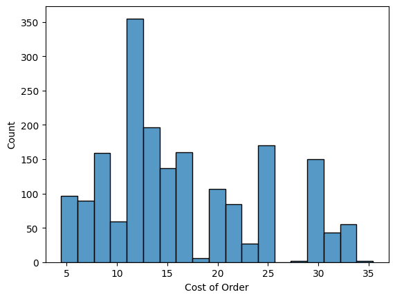

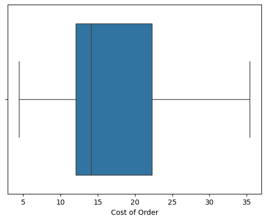

```python
# Question 6: Explore all the variables and provide observations on their distributions. (Generally, histograms, boxplots, countplots, etc. are used for univariate exploration.) [9 marks]

sns.histplot(data=foodhub_data,x='cost_of_the_order')
plt.xlabel('Cost of Order')
plt.show()
sns.boxplot(data=foodhub_data,x='cost_of_the_order')
plt.xlabel('Cost of Order')
plt.show()
```

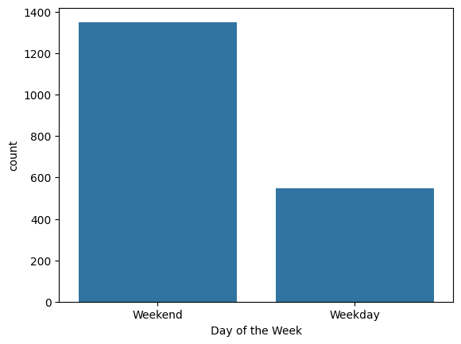

```python
# Question 6: Explore all the variables and provide observations on their distributions. (Generally, histograms, boxplots, countplots, etc. are used for univariate exploration.) [9 marks]

sns.countplot(data = foodhub_data, x = 'day_of_the_week')
plt.xlabel('Day of the Week')
```

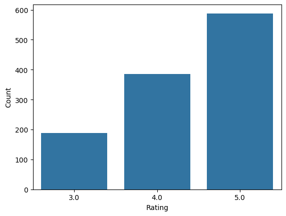

```python
# Question 6: Explore all the variables and provide observations on their distributions. (Generally, histograms, boxplots, countplots, etc. are used for univariate exploration.) [9 marks]

sns.countplot(data = foodhub_data, x = 'rating')
plt.xlabel('Rating')
plt.ylabel('Count')
```

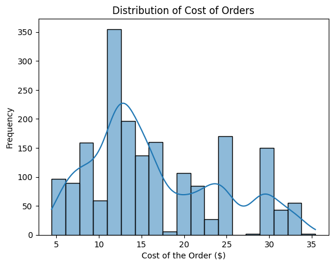

```python
# Question 6: Explore all the variables and provide observations on their distributions. (Generally, histograms, boxplots, countplots, etc. are used for univariate exploration.) [9 marks]

sns.histplot(data=foodhub_data, x='cost_of_the_order', kde=True)
plt.title('Distribution of Cost of Orders')
plt.xlabel('Cost of the Order ($)')
plt.ylabel('Frequency')
plt.show()
```

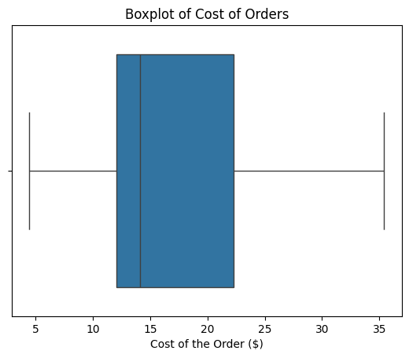

```python
# Question 6: Explore all the variables and provide observations on their distributions. (Generally, histograms, boxplots, countplots, etc. are used for univariate exploration.) [9 marks]

sns.boxplot(data=foodhub_data, x='cost_of_the_order')
plt.title('Boxplot of Cost of Orders')
plt.xlabel('Cost of the Order ($)')
plt.show()
```

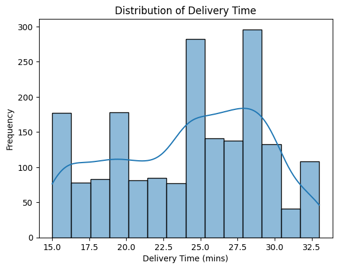

```python
# Question 6: Explore all the variables and provide observations on their distributions. (Generally, histograms, boxplots, countplots, etc. are used for univariate exploration.) [9 marks]

sns.histplot(data=foodhub_data, x='delivery_time', kde=True)
plt.title('Distribution of Delivery Time')
plt.xlabel('Delivery Time (mins)')
plt.ylabel('Frequency')
plt.show()
```

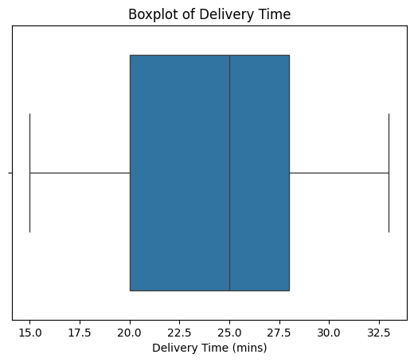

```python
# Question 6: Explore all the variables and provide observations on their distributions. (Generally, histograms, boxplots, countplots, etc. are used for univariate exploration.) [9 marks]

sns.boxplot(data=foodhub_data, x='delivery_time')
plt.title('Boxplot of Delivery Time')
plt.xlabel('Delivery Time (mins)')
plt.show()
```

[figure not shown]

```python
# Question 6: Explore all the variables and provide observations on their distributions. (Generally, histograms, boxplots, countplots, etc. are used for univariate exploration.) [9 marks]

sns.countplot(data=foodhub_data, y='restaurant_name')
plt.xlabel('Count')
plt.ylabel('Restaurant Name')
plt.show()
```

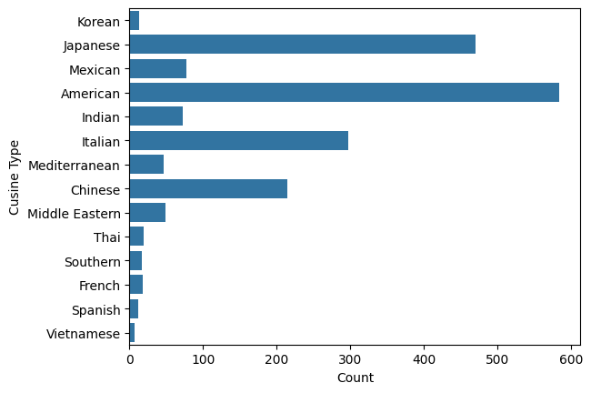

```python
# Question 6: Explore all the variables and provide observations on their distributions. (Generally, histograms, boxplots, countplots, etc. are used for univariate exploration.) [9 marks]

sns.countplot(data=foodhub_data, y='cuisine_type')
plt.xlabel('Count')
plt.ylabel('Cusine Type')
plt.show()
```

Observations Question 6: Most customers seem to prefer affordable meals, possibly because they are ordering for one person rather than groups. The histogram shows that most orders cost less than 25 dollars, with the highest concentration between 10 and 15 dollars. This suggests that customers are motivated by value and that restaurants offering bundle deals or discounts may be driving higher sales. The boxplot shows that order costs typically range from 12 to 22 dollars, with a median of around 15 dollars, reinforcing that most people spend moderately when ordering through FoodHub.

Order volume is higher on weekends compared to weekdays. This pattern likely reflects customer behavior, as people tend to treat themselves or relax with takeout after a long work week. This insight could help restaurants plan their staffing schedules more effectively by increasing staff availability on weekends when demand peaks.

Customer ratings mostly fall between 4.0 and 5.0, which suggests a high level of satisfaction with both food quality and service. The smaller number of 3.0 ratings may reflect issues related to delivery rather than food quality. Improving weekday delivery efficiency could help raise overall ratings even further.

Delivery times are generally consistent, with most orders arriving within 30 minutes. This reliability likely contributes to the high customer satisfaction levels. A few longer delivery times appear in the data, which could be due to traffic, location distance, or busy time periods. From an operational standpoint, FoodHub could optimize routes or delivery schedules to reduce these inconsistencies.

The top 3 restaurants in terms of order volume are Shake Shack, The Meatball Shop, and Blue Ribbon. This shows that customers tend to order from well-known, trusted brands rather than smaller or less established ones. In terms of cuisine, American food dominates, followed by Japanese and Italian. This trend suggests that customers gravitate toward familiar and reliable options, both in taste and price.

```python
# Question 7: Which are the top 5 restaurants in terms of the number of orders received? [1 mark]

foodhub_data['restaurant_name'].value_counts().head(5)
```

| restaurant_name | count |
| --- | --- |
| Shake Shack | 219 |
| The Meatball Shop | 132 |
| Blue Ribbon Sushi | 119 |
| Blue Ribbon Fried Chicken | 96 |
| Parm | 68 |

**dtype:** int64

```python
# Question 8: Which is the most popular cuisine on weekends? [1 mark]

weekend_data = foodhub_data[foodhub_data['day_of_the_week'] == 'Weekend']
weekend_data['cuisine_type'].value_counts()
```

| cuisine_type | count |
| --- | --- |
| American | 415 |
| Japanese | 335 |
| Italian | 207 |
| Chinese | 163 |
| Mexican | 53 |
| Indian | 49 |
| Middle Eastern | 32 |
| Mediterranean | 32 |
| Thai | 15 |
| French | 13 |
| Korean | 11 |
| Southern | 11 |
| Spanish | 11 |
| Vietnamese | 4 |

**dtype:** int64

Observations Question 8: This indicates that customers prefer familiar, comfort-style food options like burgers, fries, and sandwiches when ordering on weekends. The company could use this insight to feature more American restaurants or offer weekend promotions for popular American menu items.

```python
# Question 9: What percentage of the orders cost more than 20 dollars? [2 marks]

ordergreater= foodhub_data[foodhub_data['cost_of_the_order'] > 20]
print('The number of total orders that cost above 20 dollars is:',ordergreater.shape[0])


percentage = (ordergreater.shape[0] / foodhub_data.shape[0]) * 100
print("The percentage of orders above $20 is", round(percentage, 2),'%')
```

```
The number of total orders that cost above 20 dollars is: 555
The percentage of orders above $20 is 29.24 %
```

Observations Question 9: About 29% of customers placed orders costing more than 20 dollars, which suggests that most customers tend to prefer affordable, single person meals or moderately priced dishes. The smaller group of higher-value orders likely represents group meals or premium restaurant selections. To encourage more high value purchases, FoodHub could introduce promotions or bundle deals that make orders above 20 dollars feel more rewarding. This strategy could help increase the average order value while giving customers a sense of getting more value for their money.

```python
# Question 10: What is the mean order delivery time? [1 mark]

deliverytimemean = foodhub_data['delivery_time'].mean()
print('The average Delivery Time for orders is:', round(deliverytimemean, 2), 'minutes')
```

```
The average Delivery Time for orders is: 24.16 minutes
```

Observations Question 10: The average delivery time for orders is around 24 minutes, showing that the delivery operations are efficient. Most deliveries are complete within a reasonable time frame, which likely contributes to higher ratings. From an operational standpoint, maintaining this average delivery time is important for customer retention. FoodHub could also analyze outliers orders that took significantly longer to identify potential causes like traffic, peak hours, or busy restaurant times, and optimize routes or staffing.

```python
# Question 11: The company has decided to give 20% discount vouchers to the top 3 most frequent customers. Find the IDs of these customers and the number of orders they placed. [1 mark]

foodhub_data['customer_id'].value_counts().head(3)
```

| customer_id | count |
| --- | --- |
| 52832 | 13 |
| 47440 | 10 |
| 83287 | 9 |

**dtype:** int64

Observations Question 11: These top 3 customers show strong brand loyalty, which could be caused by consistent service quality, favorite cuisines, or personalized experiences. It's also possible that certain restaurants are offering incentives like discounts, faster delivery, or loyalty perks that keep these customers returning.FoodHub can analyzing their ordering frequency, cuisine preferences, and spending behavior could help identify what drives repeat purchases and how to expand that trend to other customers.

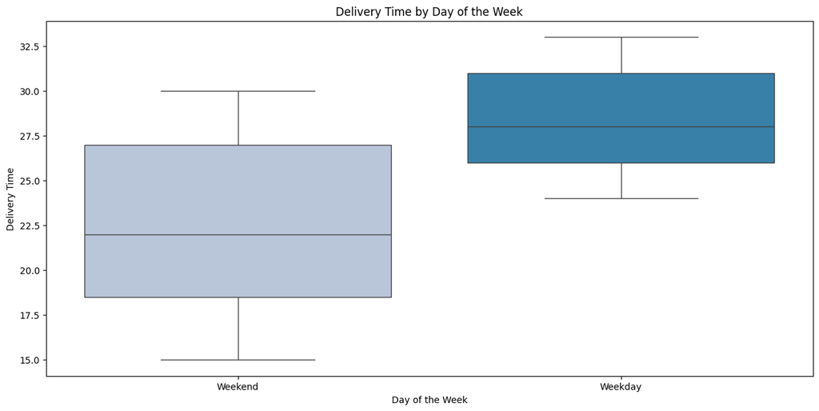

```python
#Question 12: Perform a multivariate analysis to explore relationships between the important variables in the dataset. (It is a good idea to explore relations between numerical variables as well as relations between numerical and categorical variables) [10 marks]

plt.figure(figsize=(15,7))
sns.boxplot(x='day_of_the_week', y='delivery_time', data=foodhub_data, palette='PuBu', hue='day_of_the_week')
plt.xlabel('Day of the Week')
plt.ylabel('Delivery Time')
plt.title('Delivery Time by Day of the Week')
plt.show()
```

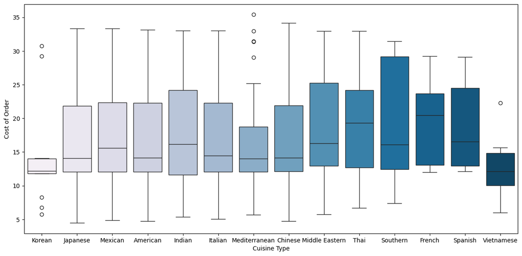

```python
#Question 12: Perform a multivariate analysis to explore relationships between the important variables in the dataset. (It is a good idea to explore relations between numerical variables as well as relations between numerical and categorical variables) [10 marks]

plt.figure(figsize=(15,7))
sns.boxplot(x = "cuisine_type", y = "cost_of_the_order", data = foodhub_data, palette = 'PuBu', hue = "cuisine_type")
plt.xlabel('Cuisine Type')
plt.ylabel('Cost of Order')
plt.show()
```

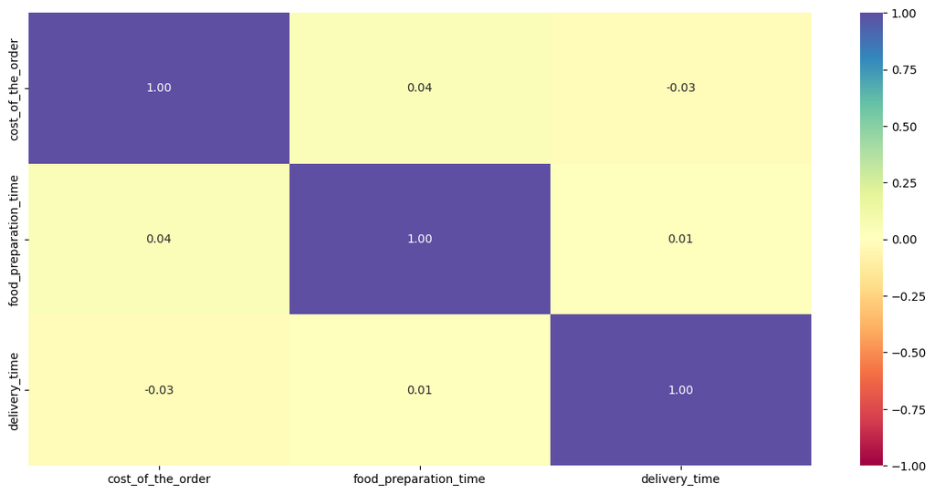

```python
#Question 12: Perform a multivariate analysis to explore relationships between the important variables in the dataset. (It is a good idea to explore relations between numerical variables as well as relations between numerical and categorical variables) [10 marks]

col_list = ['cost_of_the_order', 'food_preparation_time', 'delivery_time']
plt.figure(figsize=(15, 7))
sns.heatmap(foodhub_data[col_list].corr(), annot=True, vmin=-1, vmax=1, fmt=".2f", cmap="Spectral")
plt.show()
```

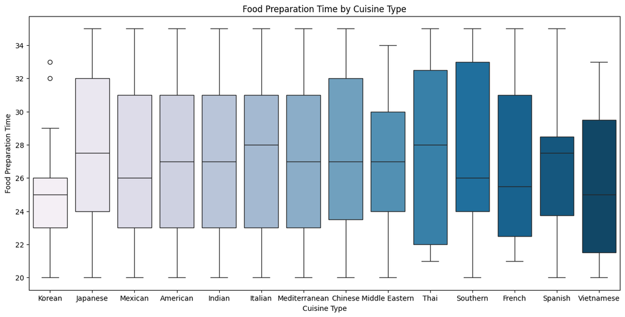

```python
#Question 12: Perform a multivariate analysis to explore relationships between the important variables in the dataset. (It is a good idea to explore relations between numerical variables as well as relations between numerical and categorical variables) [10 marks]

plt.figure(figsize=(15,7))
sns.boxplot(x='cuisine_type', y='food_preparation_time', data=foodhub_data, palette='PuBu', hue='cuisine_type')
plt.xlabel('Cuisine Type')
plt.ylabel('Food Preparation Time')
plt.title('Food Preparation Time by Cuisine Type')
plt.show()
```

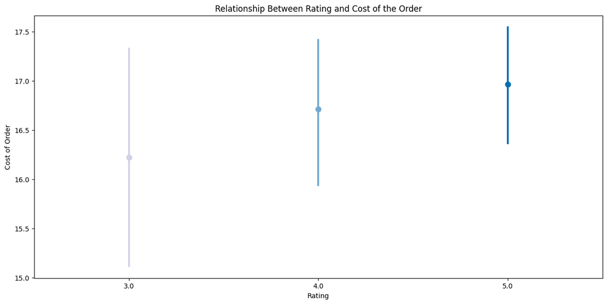

```python
#Question 12: Perform a multivariate analysis to explore relationships between the important variables in the dataset. (It is a good idea to explore relations between numerical variables as well as relations between numerical and categorical variables) [10 marks]

plt.figure(figsize=(15, 7))
sns.pointplot(x='rating', y='cost_of_the_order', data=foodhub_data, palette='PuBu')
plt.xlabel('Rating')
plt.ylabel('Cost of Order')
plt.title('Relationship Between Rating and Cost of the Order')
plt.show()
```

Observations Question 12: The box plot shows that weekend deliveries are faster than weekday deliveries, with an average delivery time of around 22 minutes on weekends compared to 28 minutes on weekdays. This suggests that FoodHub's delivery operations are more efficient on weekends, possibly due to optimized staffing when order volume is highest.